# Chapter 14 Homework

AP

Updated 2022-03-02

## Question 1

1. 1
2. left-handed: untreatedlh/treatedlh = 10/6 = 1.6667; right-handed: untreatedrh/treatedrh = 88/90 = .9778; ambidextrous: untreateda/treateda = 2/4 = .5
3. left-handed: 1.6667 $\times$ 6/(1.6667 $\times$ 6 + .9778 $\times$ 90 + .5 $\times$ 4) = 10%; right-handed: .9778 $\times$ 90/(.6 $\times$ 10 + 1.02 $\times$ 88 + 2 $\times$ 4) = 88%; ambidextrous: .5 $\times$ 4/(1.6667 $\times$ 6 + .9778 $\times$ 90 + .5 $\times$ 4) = 2%
4. (7 $\times$ 1.6667 $\times$ 6 + 4 $\times$ .5 $\times$ 4 + 6 $\times$ .9778 $\times$ 90)/100 = 6.06
5. 6.06 - 5 = 1.06 ATE

## Question 2

1. kernel matching
2. 2-nearest-neighbor distance matching
3. propensity score matching
4. 1-to-1 distance matching

## Question 3

1. option B
2. option A
3. option B
4. option A ???

## Question 4

When you interact all the variables, the resulting matrix can be REALLY BIG, so the probability of someone finding a match goes down unless you have a LOT of observations or only a FEW matching variables.

## Question 5

Step 1: Calculate Mahalanobis distance (divide each squared value of HS athleticism, parental income, gender, race, and MS grades by their respective covariance matrices, treat these as distances in 5 dimensions, use Pythagorean theorem to get distance).

Step 2: Match treatment observation 1 to the control observation that’s the closest to it.

Step 3: Match treatment observation 2 to the nearest control observation, even if it’s the same one as in step 2. Continue through n treatment observations.

Step 4: Drop any treatment observation whose closest control observation has a Mahalanobis distance of more than .3 from the sample.

Step 5: Calculate ATE of participating in high school sports using the matches.

## Question 6

D

## Question 7

1. Retail companies with 1-5 employees.
2. No. I don’t think?
3. If we use that one control over and over again, it will increase the variance.
4. Dropping observations mean we can only really estimate the treatment effect for people who matched well to controls, not for everyone who recieved treatment.

## Question 8

1. No
2. I would want to overlay the distributions of income in the treated and control group to spot big differences, and I would want to know how closely income is related to my dependent variable.
3. Try another matching method.

## Question 9

When you select untreated observations to match the treated observations, you’re essentially trying to imagine what each treated observation would look like if it hadn’t been treated. Take an ATT of college on income. You’re (imperfectly) trying to say…“In an alternate universe where I never went to college, I would look exactly like Bob (and make exactly that amount of money). So I’ll match with Bob.”

The other way around is an ATUT. You’re trying to imagine what would have happened to your untreated people if we could get them treatment. Take an ATUT of a medicine on self-rated health. You’re saying…“I haven’t taken the medicine (I can’t afford it). In an alternate universe where I was able to take the medicine, I would look exactly like Bob, because he’s exactly like me in every other way, and I’d be exactly that healthy. So I’ll match with Bob.”

## Coding Question 1

```r
nsw <- read_csv("https://vincentarelbundock.github.io/Rdatasets/csv/causaldata/nsw_mixtape.csv")

nsw <- nsw |>
  select(-c(data_id, ...1))
```

## Coding Question 2

```r
nsw <- nsw |>
  mutate(weight = 1)

m2 <- lm(re78 ~ treat,
               data = nsw,
               weights = weight)

tidy(m2)
```

```
## # A tibble: 2 × 5
##   term        estimate std.error statistic  p.value
##   <chr>          <dbl>     <dbl>     <dbl>    <dbl>
## 1 (Intercept)    4555.      408.     11.2  1.15e-25
## 2 treat          1794.      633.      2.84 4.79e- 3
```

```r
sumtable(nsw, group = "treat", group.weights = "weight")
```

Summary Statistics

| treat Variable | 0 N | 0 Wt. Mean | 0 Wt. SD | 1 N | 1 Wt. Mean | 1 Wt. SD |
| --- | --- | --- | --- | --- | --- | --- |
| age | 260 | 25.054 | 7.058 | 185 | 25.816 | 7.155 |
| educ | 260 | 10.088 | 1.614 | 185 | 10.346 | 2.011 |
| black | 260 | 0.827 | 0.379 | 185 | 0.843 | 0.365 |
| hisp | 260 | 0.108 | 0.311 | 185 | 0.059 | 0.237 |
| marr | 260 | 0.154 | 0.361 | 185 | 0.189 | 0.393 |
| nodegree | 260 | 0.835 | 0.372 | 185 | 0.708 | 0.456 |
| re74 | 260 | 2107.027 | 5687.906 | 185 | 2095.574 | 4886.62 |
| re75 | 260 | 1266.909 | 3102.982 | 185 | 1532.055 | 3219.251 |
| re78 | 260 | 4554.801 | 5483.836 | 185 | 6349.144 | 7867.402 |

The treatment group is less Hispanic and more educated than the control group.

## Coding Question 3

```r
match3 <- matchit(treat ~ age + educ + black + hisp + marr + nodegree +
                    re74 + re75,
                  data = nsw,
                  method = "nearest",
                  distance = "mahalanobis",
                  estimand = "ATT",
                  replace = TRUE)

matchdata3 <- match.data(match3)

m3 <- lm(re78 ~ treat,
         data = matchdata3,
         weights = weights
         )

tidy(m3)
```

```
## # A tibble: 2 × 5
##   term        estimate std.error statistic  p.value
##   <chr>          <dbl>     <dbl>     <dbl>    <dbl>
## 1 (Intercept)    4401.      657.      6.70 1.09e-10
## 2 treat          1948.      827.      2.36 1.92e- 2
```

## Coding Question 4

```r
bal.tab(match3)
```

```
## Call
##  matchit(formula = treat ~ age + educ + black + hisp + marr +
##     nodegree + re74 + re75, data = nsw, method = "nearest", distance = "mahalanobis",
##     estimand = "ATT", replace = TRUE)
##
## Balance Measures
##             Type Diff.Adj
## age      Contin.   0.0408
## educ     Contin.   0.0000
## black     Binary  -0.0216
## hisp      Binary  -0.0054
## marr      Binary   0.0378
## nodegree  Binary  -0.0432
## re74     Contin.   0.0742
## re75     Contin.   0.0533
##
## Sample sizes
##                      Control Treated
## All                   260.       185
## Matched (ESS)          76.91     185
## Matched (Unweighted)  108.       185
## Unmatched             152.         0
```

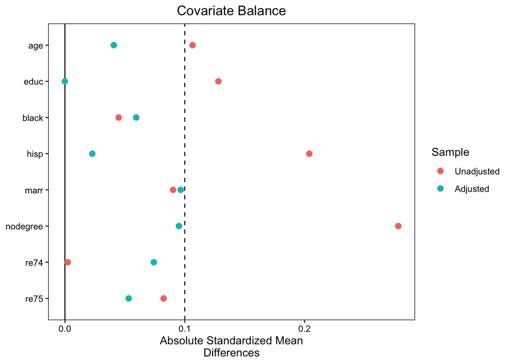

```r
love.plot(match3,
          abs = TRUE,
          binary = "std",
          thresholds = .1)
```

## Coding Question 5

```r
m5 <- glm(treat ~ age + educ + black + hisp + marr + nodegree +
               re74 + re75,
            data = nsw,
            family = binomial(link = 'logit'))

nsw <- nsw |>
    mutate(propensity = predict(m5, type = 'response')) |>
    mutate(propensity = ifelse(.95 > propensity & propensity > .05, propensity, NA_real_))
```

## Coding Question 6

```r
nsw <- nsw |>
  mutate(ipw = ifelse(treat == 1, 1/propensity, 1/(1-propensity)))
```

## Coding Question 7

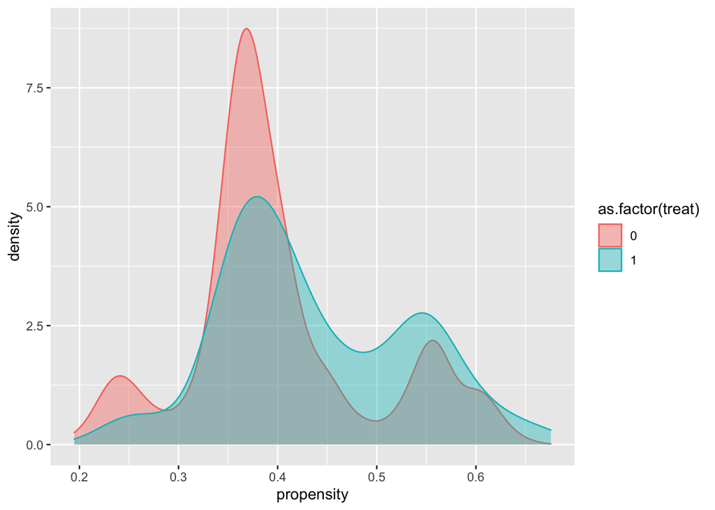

```r
ggplot(data = nsw,
       aes(x = propensity,
           color = as.factor(treat),
           fill = as.factor(treat))) +
  geom_density(alpha = .4)
```

## Coding Question 8

```r
# Function to do IPW estimation with regression adjustment
ipwra <- function(nsw, index = 1:nrow(nsw)) {
    # Apply bootstrap index
    nsw <- nsw |> slice(index)

    # Estimate difference
    w_means <- nsw |>
        group_by(treat) |>
        summarize(m = weighted.mean(re78, w = ipw)) |>
        arrange(treat)

    return(w_means$m[2] - w_means$m[1])
}

b <- boot::boot(nsw, ipwra, R = 200)
# See estimate and standard error
b
```

```
##
## ORDINARY NONPARAMETRIC BOOTSTRAP
##
##
## Call:
## boot::boot(data = nsw, statistic = ipwra, R = 200)
##
##
## Bootstrap Statistics :
##     original   bias    std. error
## t1* 1641.315 52.35872    669.7519
```